# Project Code

### 2.3.2 2: Transit Availability by Side

*By Grace Gormley*

First, I will need to scale the different per capita data, since the L is much lower than bikes and buses.

```python
from sklearn.preprocessing import MinMaxScaler, StandardScaler

cols_to_normalize = ['bus_stops_per_capita', 'L_stops_per_capita', 'bike_stops_per_capita']

standard_scaler = MinMaxScaler()
side_data_scaled = side_data.copy()
side_data_scaled[cols_to_normalize] = standard_scaler.fit_transform(side_data_scaled[cols_to_normalize])
side_data_scaled
```

|  | side | Total_Population | Total_L_Stops | Total_Bus_Stops | Total_Divvy_Stations | Total_Divvy_Rides | avg_traffic_speed_side | L_stops_per_capita | bus_stops_per_capita | bike_stops_per_capita | divvy_per_capita |
| --- | --- | --- | --- | --- | --- | --- | --- | --- | --- | --- | --- |
| 0 | CENTRAL | 156226.0 | 25.0 | 493 | 134.0 | 3734447 | 22.500000 | 1.000000 | 0.172462 | 1.000000 | 23.904132 |
| 1 | FAR NORTH SIDE | 456323.0 | 22.0 | 1241 | 119.0 | 878282 | 24.725000 | 0.301275 | 0.000000 | 0.000000 | 1.924694 |
| 2 | FAR SOUTHEAST SIDE | 209345.0 | 3.0 | 1046 | 92.0 | 20394 | 26.623188 | 0.089551 | 0.900420 | 0.299330 | 0.097418 |
| 3 | FAR SOUTHWEST SIDE | 175841.0 | 0.0 | 656 | 50.0 | 12637 | 24.487500 | 0.000000 | 0.399827 | 0.039480 | 0.071866 |
| 4 | NORTH SIDE | 296205.0 | 15.0 | 844 | 178.0 | 2968640 | 23.917808 | 0.316455 | 0.051334 | 0.569820 | 10.022248 |
| 5 | NORTH WEST SIDE | 271227.0 | 3.0 | 898 | 89.0 | 119101 | 22.896552 | 0.069120 | 0.233833 | 0.112837 | 0.439119 |
| 6 | SOUTH SIDE | 246744.0 | 14.0 | 1295 | 114.0 | 709917 | 27.386667 | 0.354564 | 1.000000 | 0.337108 | 2.877140 |
| 7 | SOUTHWEST SIDE | 358308.0 | 8.0 | 1472 | 111.0 | 48670 | 24.884058 | 0.139523 | 0.549129 | 0.082099 | 0.135833 |
| 8 | WEST SIDE | 477402.0 | 34.0 | 1983 | 250.0 | 2244765 | 22.100000 | 0.445049 | 0.567136 | 0.440383 | 4.702044 |

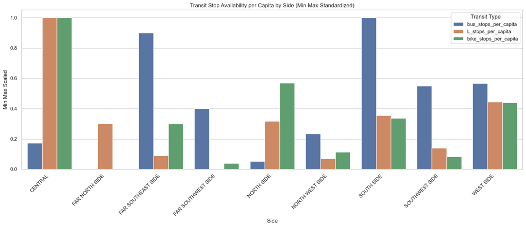

```python
df_long_scaled = side_data_scaled[['side'] + cols_to_normalize].melt(
    id_vars='side',
    value_vars=cols_to_normalize,
    var_name='Transit Type',
    value_name='Min/max Standardized Value'
)


plt.figure(figsize=(16, 7))
sns.barplot(
    x='side',
    y='Min/max Standardized Value',
    hue='Transit Type',
    data=df_long_scaled
)

plt.title('Transit Stop Availability per Capita by Side (Min Max Standardized)')
plt.ylabel('Min Max Scaled')
plt.xlabel('Side')
plt.legend(title='Transit Type')
plt.xticks(rotation=45, ha='right')
plt.tight_layout();
```

By comparing transit availability on a min/max scaler, we can see that the L stop availability and bike station availability go hand in hand, often being similarly placed in the hierarchies in the same communities. However, bus stops follow a different trend, and in some areas with a lot of bus availability, there is less bike and L availability. This may suggest strategic planning which creates a bus grid to better support communities without L access. I also had to use .melt to get this graph to work!

#### 2.3.2.1 Potential Conclusion:

This may suggest that Chicago is built with strategic planning which creates a bus grid to better support communities without L access.

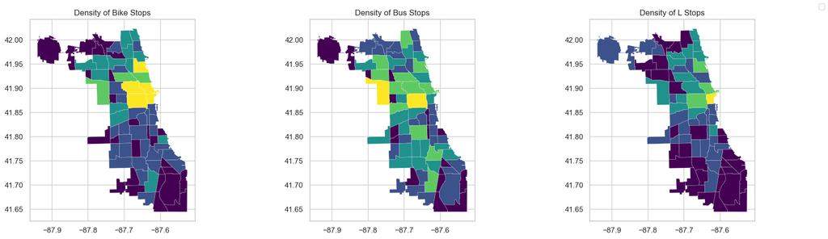

```python
fig, axes = plt.subplots(1, 3, figsize=(18, 5), sharex=False, sharey=False)

#Bike
chicago_merge.plot(
    column='num_bike_stops',
    legend=False,
    cmap='viridis',
    scheme='NaturalBreaks',
    ax=axes[0], linewidth=0.2)
axes[0].set_title("Density of Bike Stops")

#Bus stops
chicago_merge.plot(
    column='num_bus_stops',
    legend=False,
    cmap='viridis',
    scheme='NaturalBreaks',
    ax=axes[1], linewidth=0.2)
axes[1].set_title("Density of Bus Stops")

#L stops
chicago_merge.plot(
    column='num_L_stops',
    legend=False,
    cmap='viridis',
    scheme='NaturalBreaks',
    ax=axes[2],linewidth=0.2)
axes[2].set_title("Density of L Stops")

handles, labels = axes[0].get_legend_handles_labels()
fig.legend(handles, labels, loc='upper right')

plt.tight_layout();
```

We can see here that total bike stops and total L stops are lacking in the south sides of Chicago, whereas bus coverage is a bit higher. Sill, transit options are lacking in these communities, which also correlate with lower incomes, if you look at Alexa’s median household income graph. This suggests that these regions are lacking in transit opportunities, and may benefit from increased Divvy coverage, which leads into my reccommendation.

#### 2.3.2.2 Potential Suggestion:

Perhaps Divvy can identify the communities that are lacking in alternate transit options and provide a higher concentrations of bike stops there to supplement the network. Hyde park may be a success story.